# Differential Analysis of State Donations by Ravin Kumar

# Abstract

At time of writing it is November 2015 and the 2016 election year is only months away. Since there is no incumbent both parties are running multiple candidates. As a result my curiosity in way candidates fund their campaigns is higher than usual.

The Federal Election Commission requires that candidates publish details of the contributions publically. The dataset holds numerous interesting pieces of information, including contribution amount, donor size code, time of donation etc. I chose to analyze the contributions from California and Wisconsin only. This is an arbitrary choice, made largely because at different points in time I have been registered to vote in each state.

# Data Munging

Double checking columns of interest to ensure everything looks ok

```
##
##    2008    2012    2016    2018    2102    <NA>
##     180 1033719   61691       1       2     163
```

```
##
##    2012    2016    2018    <NA>
## 1033721   61691       1     163
```

[output not shown]

```
##       cmte_id         cand_id                  cand_nm
##  C00410118:  0   P00003608:  0   Bachmann, Michele :  0
##  C00431171:  0   P20002523:  0   Cain, Herman      :  0
##  C00431445:  0   P20002556:  0   Gingrich, Newt    :  0
##  C00493692:  0   P20002671:  0   Huntsman, Jon     :  0
##  C00494393:  0   P20002721:  0   Johnson, Gary Earl:  0
##  (Other)  :  0   (Other)  :  0   (Other)           :  0
##  NA's     :163   NA's     :163   NA's              :163
##                   contbr_nm               contbr_city  contbr_st
##  ''WILSON,'', ANIL     :  0                     :  0   CA  :  0
##  ..., ANTHONY          :  0   /RANCHO PALOS /VER:  0   WI  :  0
##  `DIRINGER, KATHLEEN   :  0   @GMAIL.COM        :  0   NA's:163
##  1519 SANTA ROSA L.L.C.:  0   <OUNTAIN VIEW     :  0
##  A'HEARN, ANYA         :  0   0644HIDDEN HILLS  :  0
##  (Other)               :  0   (Other)           :  0
##  NA's                  :163   NA's              :163
##    contbr_zip                                contbr_employer
##         :  0                                         :  0
##  *9040  :  0   -                                     :  0
##  *9136  :  0   -SELF-                                :  0
##  *9211  :  0    FAIRCHILD SEMI                       :  0
##  *9250  :  0   (CURRENTLY DISTINGUISHED VISITING PROF:  0
##  (Other):  0   (Other)                               :  0
##  NA's   :163   NA's                                  :163
##                    contbr_occupation contb_receipt_amt contb_receipt_dt
##                             :  0     Min.   : NA       Min.   :NA
##  -                          :  0     1st Qu.: NA       1st Qu.:NA
##   BUILDING TECH             :  0     Median : NA       Median :NA
##   REGISTERED NURSE          :  0     Mean   :NaN       Mean   :NA
##   SIMUNYE TRUST & FOUNDATION:  0     3rd Qu.: NA       3rd Qu.:NA
##  (Other)                    :  0     Max.   : NA       Max.   :NA
##  NA's                       :163     NA's   :163       NA's   :163
##                                                       receipt_desc
##                                                             :  0
##  ATTRIBUTION TO PARTNERS REQUESTED / REDESIGNATION REQUESTED:  0
##  EARMARK:  ACTRIGHT.COM PAC; REDESIGNATION FROM PRIMARY     :  0
##  EARMARK:  ACTRIGHT.COM PAC; REDESIGNATION TO GENERAL       :  0
##  EARMARK: ACTRIGHT.COM PAC; REDESIGNATION FROM PRIMARY      :  0
##  (Other)                                                    :  0
##  NA's                                                       :163
```

[output cut: 9 more lines]

```
##  Min.   : NA   0000002     :  0          :  0   Mode:logical
##  1st Qu.: NA   0000004-0001:  0   G2008  :  0   NA's:163
##  Median : NA   0000007     :  0   G2012  :  0
##  Mean   :NaN   0000013     :  0   O2012  :  0
##  3rd Qu.: NA   0000020     :  0   P      :  0
##  Max.   : NA   (Other)     :  0   (Other):  0
##  NA's   :163   NA's        :163   NA's   :163
##  election_year election_type
##  Min.   : NA   Length:163
##  1st Qu.: NA   Class :character
##  Median : NA   Mode  :character
##  Mean   :NaN
##  3rd Qu.: NA
##  Max.   : NA
##  NA's   :163
```

Further exploration seems to show that the null values in the memo columns are represented as *.

```
##
##             X
## 855975 239438
```

The memo columns are of little interest at this moment so we’ll continue on.

### Negative Values

We except contributions to be positive, so were checking for negative values in the contribution

```
##       cmte_id   cand_id           cand_nm                contbr_nm
## 225 C00495820 P80000748         Paul, Ron     GONZALEZ, JOHN LOUIS
## 318 C00496497 P60003654    Gingrich, Newt             MURRAY, JOHN
## 354 C00496497 P60003654    Gingrich, Newt      NELSON, DOUGLAS MR.
## 407 C00496497 P60003654    Gingrich, Newt LIGHTCAP, CONNIE M. MRS.
## 432 C00410118 P20002978 Bachmann, Michele             MINNIS, RITA
## 528 C00496497 P60003654    Gingrich, Newt            KREBS, DONALD
##      contbr_city contbr_st contbr_zip               contbr_employer
## 225     LA JOLLA        CA  920377444                          SELF
## 318  GRANITE BAY        CA  957466801 WESTPARKASSOCIATES ASSOCIATES
## 354 SAN CLEMENTE        CA  926724369                       RETIRED
## 407      ONTARIO        CA  917614513      LIGHTCAP INDUSTRIES INC.
## 432     MILPITAS        CA  950357610
## 528 NEWBURY PARK        CA  913204302     ACCESS TO RECREATION INC.
##     contbr_occupation contb_receipt_amt contb_receipt_dt
```

[output cut: 27 more lines]

Each refund actually negates a donation. To calculate the ratio then we take the number of refunds and divide it by the position donations less the refunds. This gives a ratio of refunds to true donations.

```
## [1] -0.03140165
```

```
## [1] 0.01046834
```

In the case with California and Wisconsin the refunds are about 3% of the total donations by dollar, and about 1% by number. This suggests that the people donating large sums of money are the ones who tend to receive refunds. This analysis is flawed somewhat because it is difficult to tell if someone received a donation, and then a refund, and then donated again. Since they’re both low numbers we’ll separate the negative contribution amounts into another dataframe and continue our analysis with only the positive contributions.

# Univariate Analysis

```
##       cmte_id            cand_id                          cand_nm
##  C00431445:769252   P80003338:769252   Obama, Barack          :769252
##  C00431171:213421   P80003353:213421   Romney, Mitt           :213421
##  C00495820: 21059   P80000748: 21059   Paul, Ron              : 21059
##  C00575795: 16386   P00003392: 16386   Clinton, Hillary Rodham: 16386
##  C00577130: 15733   P60007168: 15733   Sanders, Bernard       : 15733
##  C00573519:  8787   P60005915:  8787   Carson, Benjamin S.    :  8787
##  (Other)  : 39543   (Other)  : 39543   (Other)                : 39543
##                 contbr_nm              contbr_city     contbr_st
##  HENRY, MICHELLE     :    272   LOS ANGELES  : 73413   CA:1000680
##  GROVER-MCKAY, MALEAH:    245   SAN FRANCISCO: 62263   WI:  83501
##  BERKE, DAVID MICHAEL:    237   SAN DIEGO    : 38485
##  BRYANT, REGINA      :    223   OAKLAND      : 24823
##  REYNOLDS, MARK      :    185   SAN JOSE     : 20183
##  RACCIO, KYLE        :    178   SACRAMENTO   : 18002
##  (Other)             :1082841   (Other)      :847012
##    contbr_zip                                    contbr_employer
##  94114  :   2839   RETIRED                               :217974
##  94110  :   2554   SELF-EMPLOYED                         :144590
##  94611  :   2210   NOT EMPLOYED                          : 77845
##  94117  :   2125   INFORMATION REQUESTED PER BEST EFFORTS: 25093
##  90046  :   1692   INFORMATION REQUESTED                 : 23428
##  (Other):1072757   (Other)                               :594821
##  NA's   :      4   NA's                                  :   430
##                               contbr_occupation  contb_receipt_amt
##  RETIRED                               :246431   Min.   :    0.01
##  ATTORNEY                              : 35195   1st Qu.:   25.00
##  HOMEMAKER                             : 25688   Median :   50.00
##  INFORMATION REQUESTED PER BEST EFFORTS: 23949   Mean   :  210.43
##  INFORMATION REQUESTED                 : 21514   3rd Qu.:  125.00
##  (Other)                               :731298   Max.   :30000.00
##  NA's                                  :   106
##  contb_receipt_dt
##  Min.   :2011-01-01 00:00:00
##  1st Qu.:2012-07-10 00:00:00
##  Median :2012-09-19 00:00:00
##  Mean   :2012-10-01 19:36:48
##  3rd Qu.:2012-10-19 00:00:00
##  Max.   :2015-09-30 00:00:00
##
```

[output cut: 17 more lines]

```
##  Min.   : 723511   SA17.474341:      4   G2012  :576487   Mode:logical
##  1st Qu.: 810684   SA17.478662:      4   P2012  :446280   NA's:1084181
##  Median : 821325   SA17.505642:      4   P2016  : 59557
##  Mean   : 840415   SA17.507073:      4   G2016  :   882
##  3rd Qu.: 846396   SA17.512921:      4   O2012  :   684
##  Max.   :1029674   SA17.1756  :      3   O2016  :   288
##                    (Other)    :1084158   (Other):     3
##  election_year  election_type
##  Min.   :2012   Length:1084181
##  1st Qu.:2012   Class :character
##  Median :2012   Mode  :character
##  Mean   :2012
##  3rd Qu.:2012
##  Max.   :2018
##
```

From the 19 columns are the fields are either categorical, an encoding, or human readable text. We will take a look at these further before exploring visualizations

```
##  [1] Paul, Ron                      Obama, Barack
##  [3] Gingrich, Newt                 Bachmann, Michele
##  [5] McCotter, Thaddeus G           Pawlenty, Timothy
##  [7] Roemer, Charles E. 'Buddy' III Perry, Rick
##  [9] Cain, Herman                   Romney, Mitt
## [11] Santorum, Rick                 Huntsman, Jon
## [13] Johnson, Gary Earl             Stein, Jill
## [15] Sanders, Bernard               Rubio, Marco
## [17] Cruz, Rafael Edward 'Ted'      Kasich, John R.
## [19] Christie, Christopher J.       Webb, James Henry Jr.
## [21] Walker, Scott                  Lessig, Lawrence
## [23] Trump, Donald J.               Carson, Benjamin S.
## [25] Pataki, George E.              Graham, Lindsey O.
## [27] Fiorina, Carly                 Jindal, Bobby
## [29] Perry, James R. (Rick)         Clinton, Hillary Rodham
## [31] Paul, Rand                     Bush, Jeb
## [33] O'Malley, Martin Joseph        Huckabee, Mike
## [35] Santorum, Richard J.
## 35 Levels: Bachmann, Michele Cain, Herman Gingrich, Newt ... Webb, James Henry Jr.
```

Looking at the names of the candidates it seems that there are only 35 people that have registered their donations in the 2012 and 2016 elections from California and Wisconsin. Due to the size of the population in California I expect all major candidates to be included on this list.

```
## 'data.frame':    1084181 obs. of  1 variable:
##  $ contbr_city: Factor w/ 3339 levels "","/RANCHO PALOS /VER",..: 1706 1145 2037 2083 414 1258 166 1722 1853 2011 ...
```

From both states only 3339 cities are listed. I would have expected more

```
##         contbr_city
##  LOS ANGELES  : 73413
##  SAN FRANCISCO: 62263
##  SAN DIEGO    : 38485
##  OAKLAND      : 24823
##  SAN JOSE     : 20183
##  SACRAMENTO   : 18002
##  (Other)      :847012
```

Looking at the top contributors the results aren’t surprising. All are Californian cities that have large populations. Although New York wasn’t included on this list I would expect it too would have a similar amount of donations.

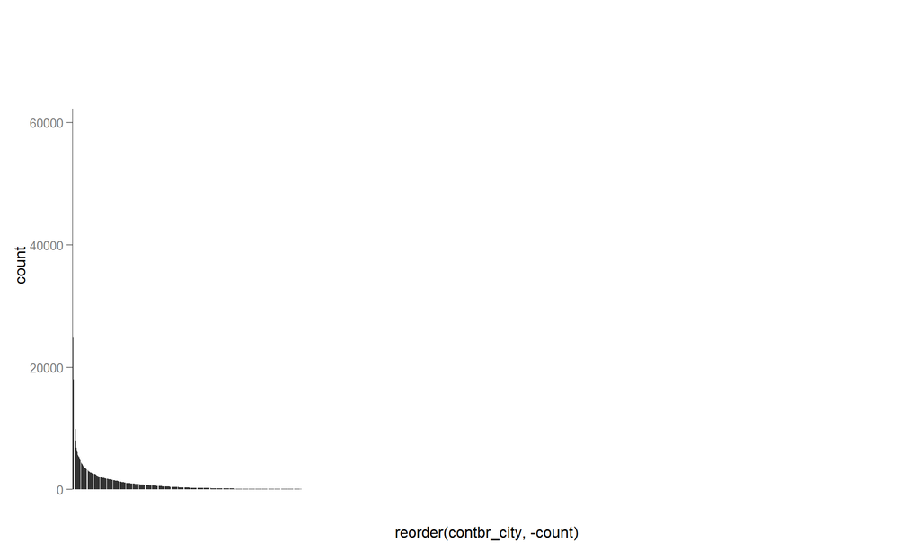

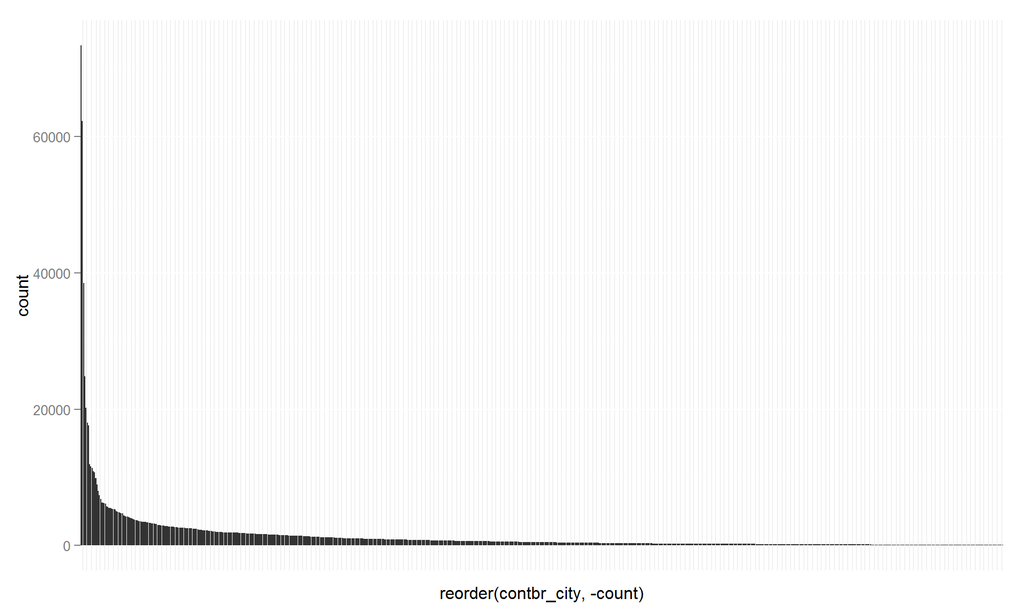

The chart is much easier to read in this one. The trend is much more clear that very few cities have more than 40000 contributors with the vast majority having 20000 or less

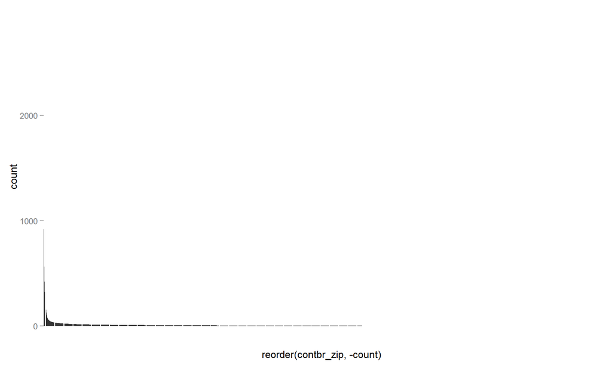

We can see the same trend with zip code. However it once again is difficult to tell the details at this scale.

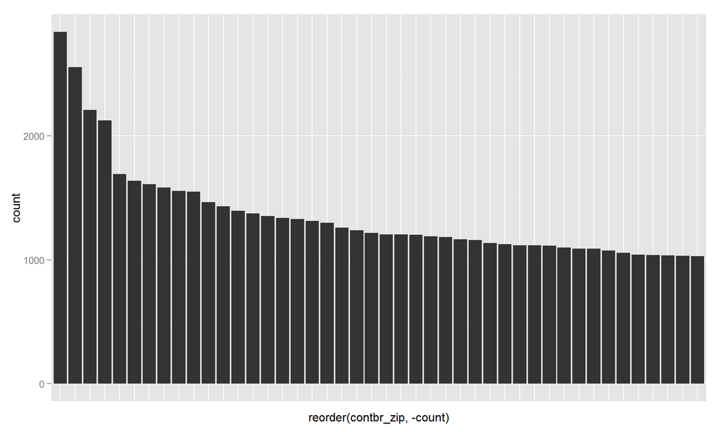

In this case the slope is much more smooth. This is likely because large cities are composed of multiple zip codes so the contributions are split up. Likewise smaller cities are grouped together.  
Moving onto the contributions themselves.

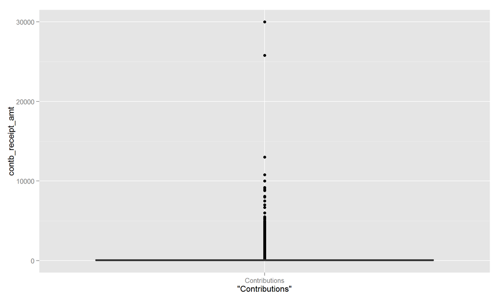

With a linear scale its clear that the range of donations is quite large, with the top donors giving about 30,000 dollars. However with this scale its hard to tell what the majority of the population is doing, specially the interquartile range and the median

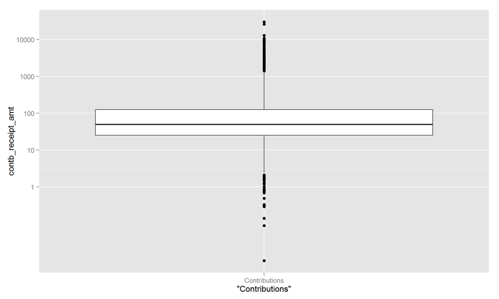

It’s a lot easier to see now. Looks like most of the donations are between 10 and a 100 dollars.

```
##  contb_receipt_amt
##  Min.   :    0.01
##  1st Qu.:   25.00
##  Median :   50.00
##  Mean   :  210.43
##  3rd Qu.:  125.00
##  Max.   :30000.00
```

A quick check shows the median at 50 dollars and as expected very close to what we can visually infer from the plot.

The other relevant columns are explored in more detail below in the bivariate and multivariate sections.

# Bivariate Plots Section

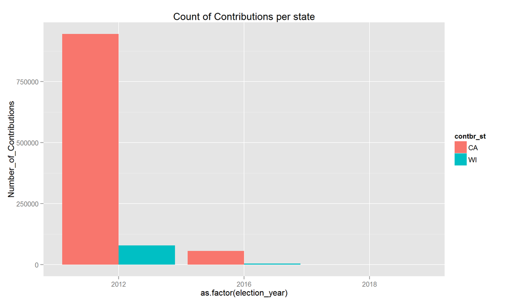

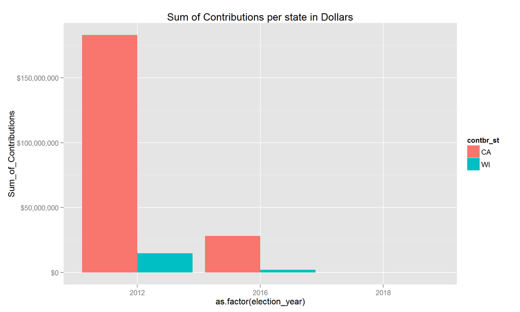

It’s no surprise that Calfornia far outpaces Wisconsin in both the count and dollar value of contributions as California is much more populous. For both graphs it would be desirable to show the values as ratio of the populations. A quick Google search shows that the population of Wisconsin at 2014 is around 5.7 million people. For California it averages around 38.2 million. As there is no 2015 data, and obviously no 2016 data. Looking back to 2012 the state population changed less than 3% for each. As is such for simplicity we’ll just the 2014 reported population to normalize the data’

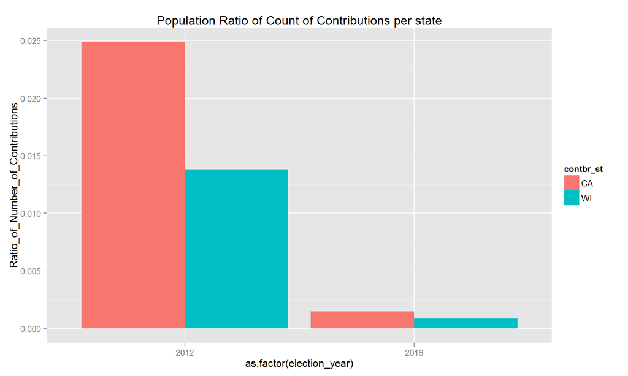

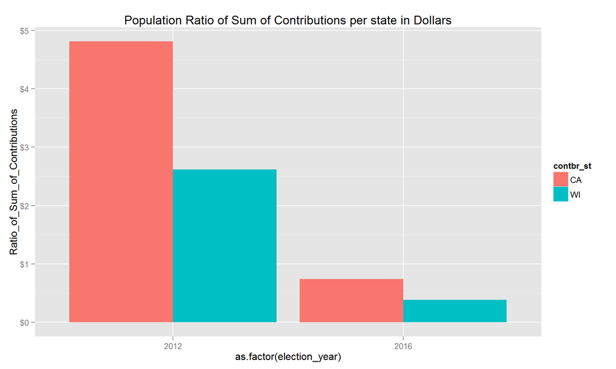

Even after after accounting for the population it seems that people from Wisconsin donated less per year, and also less people from Wisconsin donated to political campaigns.

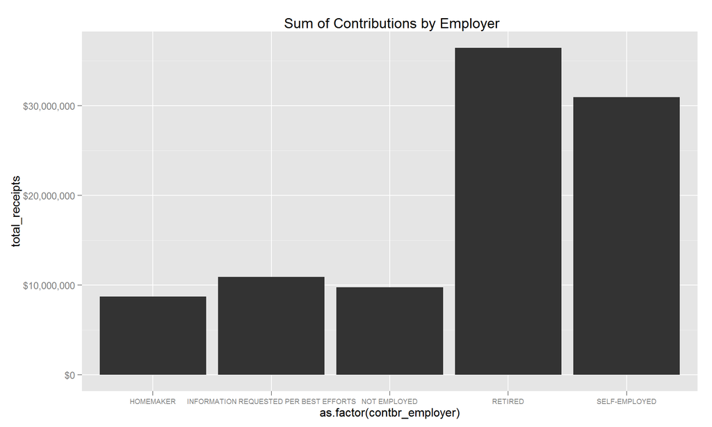

Initially was expecting a list of company names to come up, but after looking at the top 5 it’s clear that these are general employment categories, instead of specific employers. For instance this is why the categories of retired and self employed come up as the highest contributors.

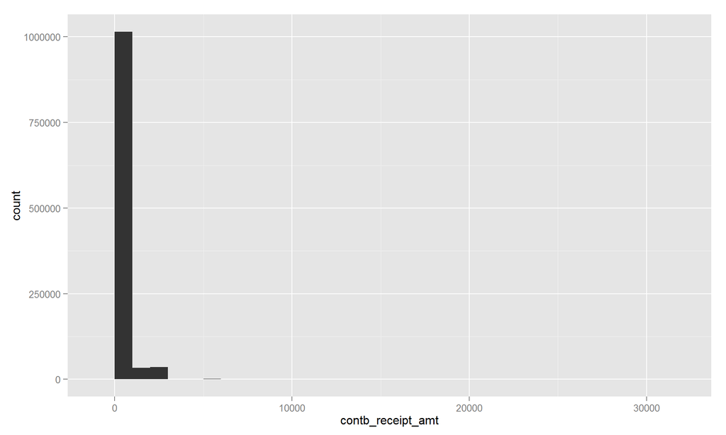

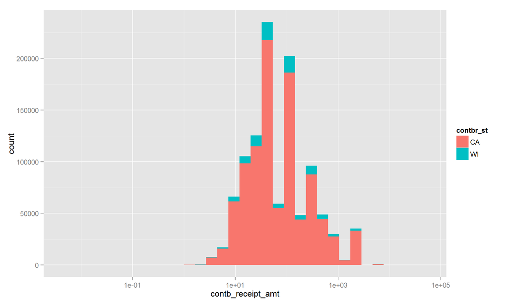

Scaling and adding color gives us some more detail. Seems like most people contribute between 10 and 100 dollars. This matches our boxplot from the earlier analysis when we were not distinguishing between the two states.

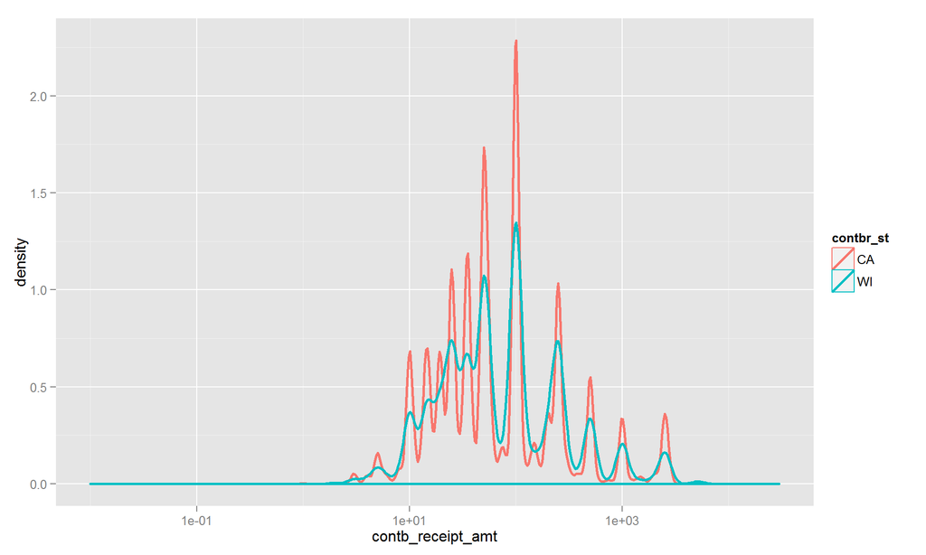

The waviness is very apparent now. It seems that most people donate round figures, most likely increments of five. Let’s quickly test this theory

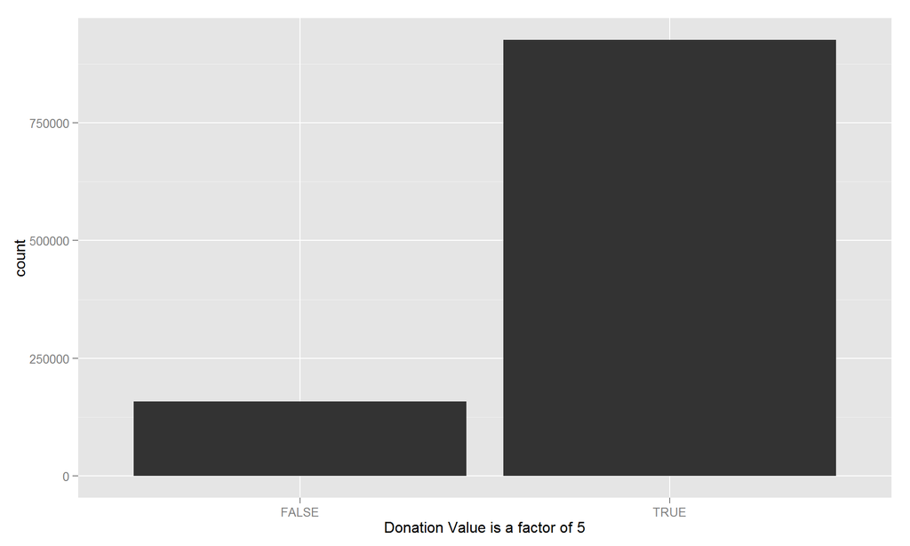

Overwhelmingly this is the case. Based off of personal experience donations are usually round numbers with 5 being the lowest divisor.

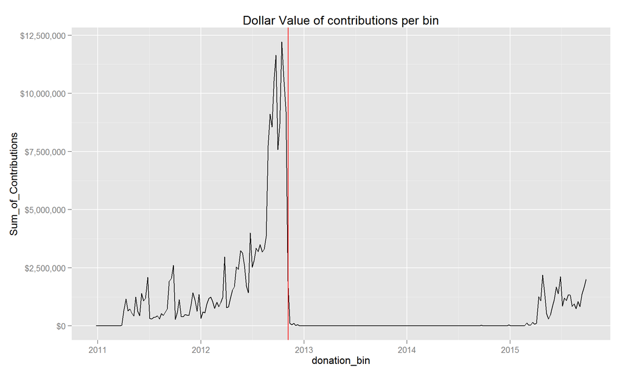

Another point of curiosity is how contributions trend over time. Plotting the sum of contribution we can see a very interesting cycle. For the 2012 election we can see the sum of the donations starting low in 2011, then quickly rising until election day where they seem to completely cease. Between the end of 2012 until the start of 2015 there is almost not activity. However we can see the start of the trend again in 2015.

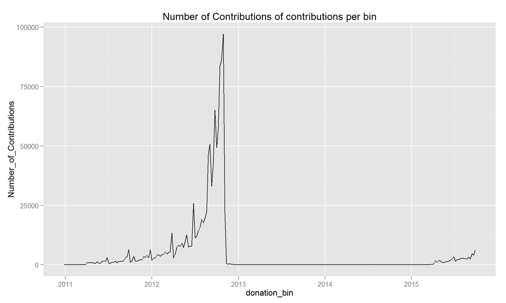

Plotting the number of contributions shows a similar story. This curve however is much smoother and looks moreso like an exponentional curve.

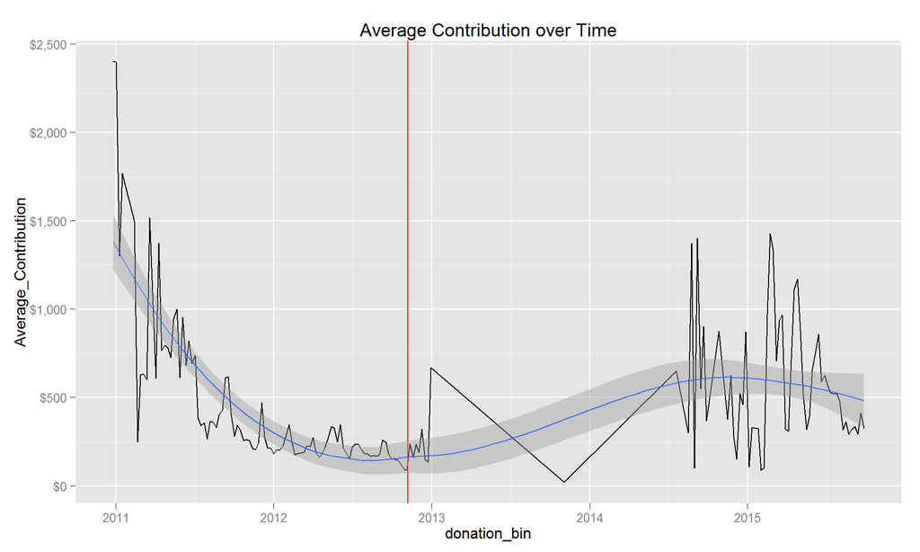

Also of interest is how the average contribution changes over time. It seems like the average contribution is much higher earlier in the election year, and as we move through the year the average contribution drops. While I didn’t expect this I suspect that early in the year rich donors are the majority of contributors, but as we move through the year more and more people participate driving the mean down.

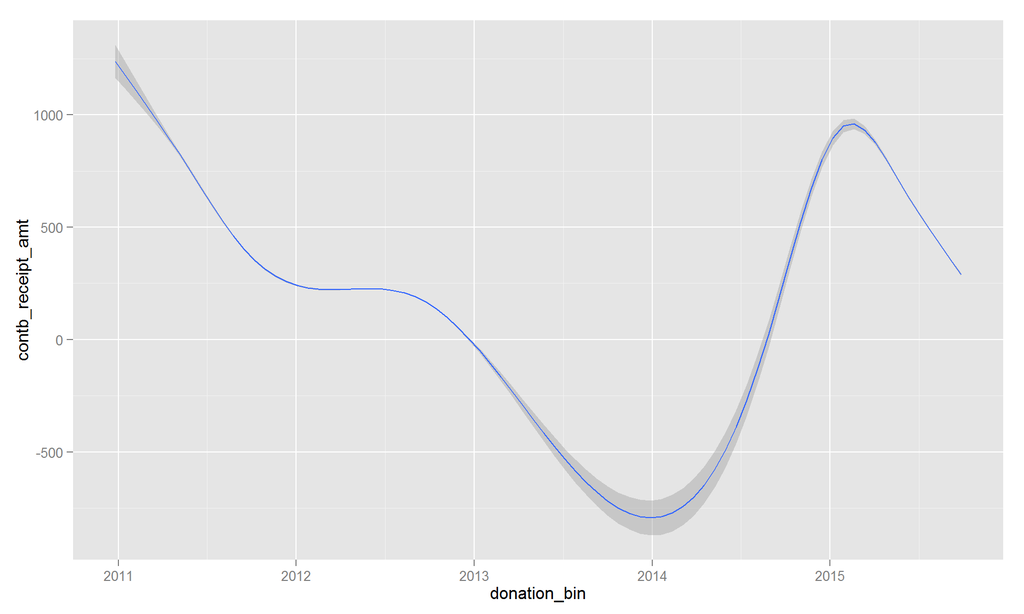

# Multivariate Analysis

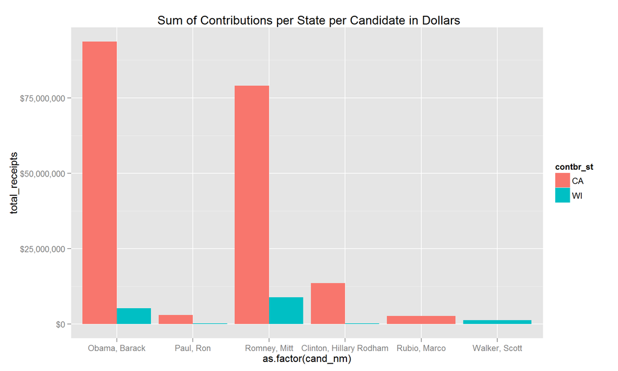

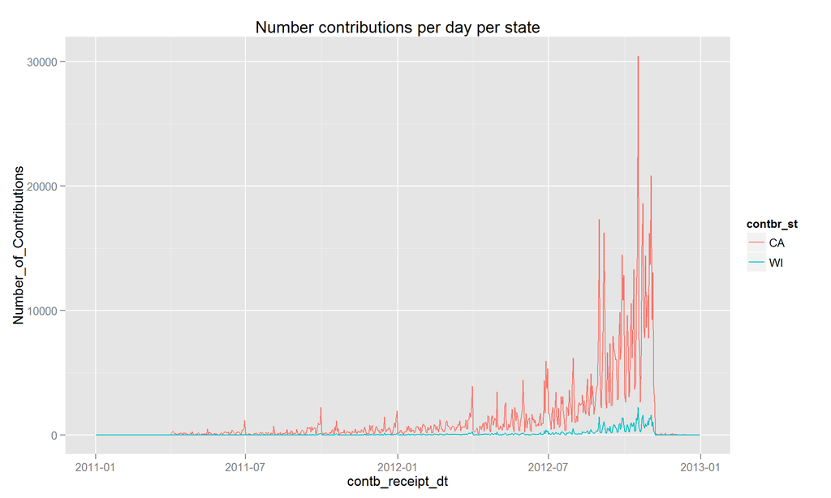

Focusing just on 2012 we can see exponentional growth leading up until the election after which the donations precipitously drop. Roughly looking at contributions between states donations from California seem to quickly grow duirng the summer of the election, leading up to the election

[figure not shown]

This plot is very interseting as it shows an up to date sum of contributions of the candidates over time. I’m fairly surprised by this plot, firstly that Donald Trump isn’t on the list at all, but also that Hilary’s contributions are far higher than any of the other candidates. Another interesting trend is Jeb’s Bush’s declining contributions. From speculation I am curious of this has anything to do with Donald Trump’s position in the rave. Conversely though it’s also interesting that Bernie Sanders contributions are increasing fairly consistently month over month. This may be a good indicator of his popularity as he gains more notoriety. ——

# Final Plots and Summary

### Plot One

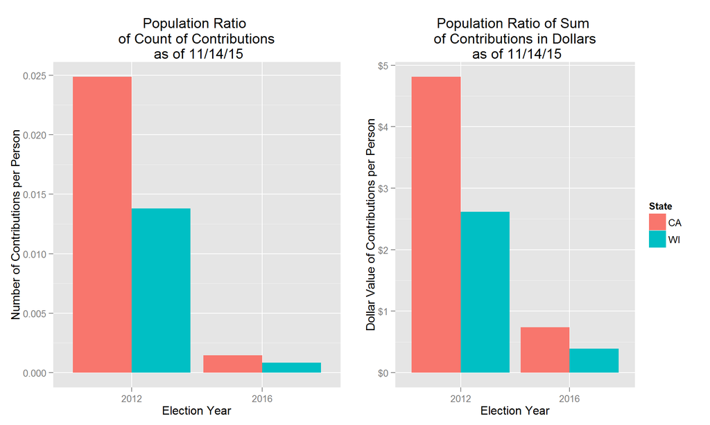

When comparing the campaign contributions between the states of California and Wisconsin an obvious question is which state contributes more, both financially and by the numbers. A simple count or sum of contributions is relatively meaningless however due to the population differences between the states. California is roughly 7 times more populous than Wisconsin so as expected more dollars and contributions come from California. However even after normalizing for population it seems that more Californians donate to campaigns, and the per person dollar contribution is higher. I’m not surprised that the dollar contribution is higher between states as California has many more wealthy people, but I am surprised that more Californians donate as a ratio of the population than Wisconsin. Wisconsin is a much older state with much more American history and families that have been American for multiple generations but for some reason it seems they’re less involved in politics by this metric.

### Plot Two

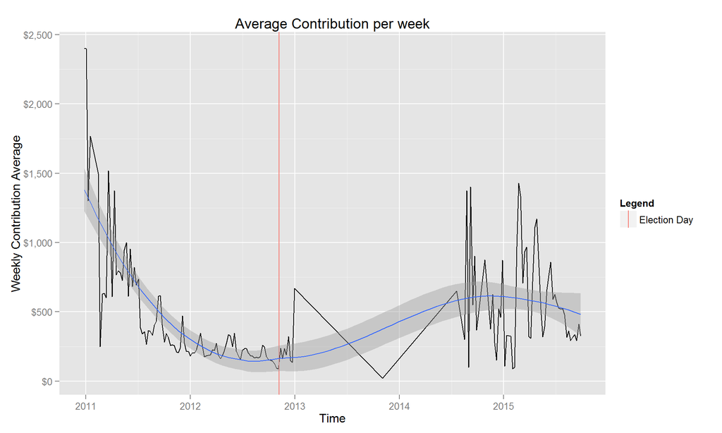

An interesting relationship can be found when looking at the average contributions over time. It seems that the first donations in the 2012 election were quite large, and as the 2012 election season went on the average contribution dropped. I suspect that as the election cycle went more middle or lower class donors started participating, whereas earlier in the election relatively richer folks were donating.

### Plot Three

[figure not shown]

This plot is interesting to me for those who are included, as well as those who weren’t. The most outspoken candidate, Donald Trump, doesn’t show in thie plot at all. However a much smaller candidate, Scott Walker, does. Additionally each candidates plots look very different. I would have expected each candidates contributions to start low, and slowly rise, but in this graphic only Bernie Sanders follows this trend. Hillary Clinton’s donations are erratic, starting very high then dropping, then rising again. Jeb Bush seems to get less donations from the two states over time. However Scott Walker sees a spike, only to have his donations drop off, likely has he withrew his candidacy soon after.

# Reflection

It is interesting how much a public dataset can reveal about the populations of two states. By downloading each dataset and aggregating the information, numerous global trends could be observed. Some of them were unsurprising, such as Wisconsin being more Republican and donating to it’s governer more than California, but others were surprising, such as California’s larger share of political contributions.

The public data initially seemed tidy and straightforward but numerous hidden issues lurked in the data. This included zip codes that included characters in their code, typo values for contribution years, and refunds. As is true of most data projects a significant amount of time was needed to find and clear these issues before proceeding.

The subsequent analysis was interesting though. The dplyr package made it very simple to aggregate the information in various ways to highlight trends. Passing these summarised dataframes to ggplot made for quick visualizations.

My biggest reason for picking this dataset though is that it is constantly changing. I’ll be rerunning this file at various points through the upcoming year. It’ll be interesting to see if I can predict any trends about candidates. Would a declining contribution amount indicate that a candidate is about to drop out? Or will the number of contributions predict which candidate will win the primary in each respective state? I could also expand this to other states besides California and Wisconsin. It’ll be interesting to see how the trends evolve and bestof all it’ll be very easy to update these visualizations to stay current.

# Appendix

## File Links

http://www.fec.gov/disclosurep/pnational.do  
ftp://ftp.fec.gov/FEC/Presidential_Map/2012/P00000001/P00000001-CA.zip  
ftp://ftp.fec.gov/FEC/Presidential_Map/2012/P00000001/P00000001-WI.zip  
ftp://ftp.fec.gov/FEC/Presidential_Map/2016/P00000001/P00000001-CA.zip  
ftp://ftp.fec.gov/FEC/Presidential_Map/2016/P00000001/P00000001-WI.zip

# Project Rubric

https://docs.google.com/document/d/1L2Wwofs6D8Crd0QLZ1-RxBHlVoBZ3mec2xWgxrmUs5I/pub?embedded=true

# Examples

https://s3.amazonaws.com/udacity-hosted-downloads/ud651/diamondsExample.html  
https://s3.amazonaws.com/udacity-hosted-downloads/ud651/AtlanticHurricaneTracking.html  
https://s3.amazonaws.com/udacity-hosted-downloads/ud651/GeographyOfAmericanMusic.html

# Dataset Reference

ftp://ftp.fec.gov/FEC/Presidential_Map/2016/DATA_DICTIONARIES/CONTRIBUTOR_FORMAT.txt  
https://docs.google.com/document/d/1qEcwltBMlRYZT-l699-71TzInWfk4W9q5rTCSvDVMpc/pub?embedded=true